# Biostat 203B Homework 5

Due Mar 22 @ 11:59PM

Author

Chengwu Duan and 606332825

## Predicting ICU duration

Using the ICU cohort `mimiciv_icu_cohort.rds` you built in Homework 4, develop at least three machine learning approaches (logistic regression with enet regularization, random forest, boosting, SVM, MLP, etc) plus a model stacking approach for predicting whether a patient’s ICU stay will be longer than 2 days. You should use the `los_long` variable as the outcome. Your algorithms can use patient demographic information (gender, age at ICU `intime`, marital status, race), ICU admission information (first care unit), the last lab measurements before the ICU stay, and first vital measurements during ICU stay as features. You are welcome to use any feature engineering techniques you think are appropriate; but make sure to not use features that are not available at an ICU stay’s `intime`. For instance, `last_careunit` cannot be used in your algorithms.

### 1.

Data preprocessing and feature engineering.

**Answer:** Done in hw5Preprocess.qmd, the output mimiciv_icu_cohort_postprocessed.rds will be used here as source rds.

```r
# Load libraries
library(GGally)
library(gtsummary)
library(ranger)
library(keras)
library(stacks)
library(tidyverse)
library(tidymodels)
library(vip)
library(ggplot2)

# load data
mimiciv_icu_cohort <- read_rds("./mimiciv_icu_cohort_postprocessed.rds")
```

### 2.

Partition data into 50% training set and 50% test set. Stratify partitioning according to `los_long`. For grading purpose, sort the data by `subject_id`, `hadm_id`, and `stay_id` and use the seed `203` for the initial data split. Below is the sample code.

```r
set.seed(203)

# sort
mimiciv_icu_cohort <- mimiciv_icu_cohort %>%
  arrange(subject_id, hadm_id, stay_id)

data_split <- initial_split(
  mimiciv_icu_cohort,
  # stratify by los_long
  strata = "los_long",
  prop = 0.5
  )

mimic_train <- training(data_split)
dim(mimic_train)
```

```
[1] 36590    27
```

```r
mimic_test <- testing(data_split)
dim(mimic_test)
```

```
[1] 36591    27
```

```r
# checking for missing values
summary(mimiciv_icu_cohort)
```

```
   subject_id          hadm_id            stay_id
 Min.   :10000032   Min.   :20000094   Min.   :30000153
 1st Qu.:12491257   1st Qu.:22483349   1st Qu.:32489353
 Median :14998941   Median :24969636   Median :34993892
 Mean   :14998189   Mean   :24981328   Mean   :34992735
 3rd Qu.:17513267   3rd Qu.:27471796   3rd Qu.:37488401
 Max.   :19999987   Max.   :29999828   Max.   :39999810

                                          first_careunit
 Cardiac Vascular Intensive Care Unit (CVICU)    :11582
 Medical Intensive Care Unit (MICU)              :15898
 Medical/Surgical Intensive Care Unit (MICU/SICU):12733
 Surgical Intensive Care Unit (SICU)             :11161
 Other                                           :21807


                     admission_type               admission_location
 EW EMER.                   :38672   EMERGENCY ROOM        :35881
 OBSERVATION ADMIT          : 8974   PHYSICIAN REFERRAL    :16398
 SURGICAL SAME DAY ADMISSION: 7373   TRANSFER FROM HOSPITAL:15798
 URGENT                     :12453   Other                 : 5104
 Other                      : 5709


  insurance           language         marital_status           race
 Length:73181       Length:73181       Length:73181       ASIAN   : 2155
 Class :character   Class :character   Class :character   BLACK   : 7960
 Mode  :character   Mode  :character   Mode  :character   HISPANIC: 2741
                                                          WHITE   :49569
                                                          Other   :10756


    gender            age_intime      bicarbonate       chloride
 Length:73181       Min.   : 18.00   Min.   : 2.00   Min.   : 45.0
 Class :character   1st Qu.: 54.00   1st Qu.:22.00   1st Qu.: 98.0
 Mode  :character   Median : 66.00   Median :25.00   Median :102.0
                    Mean   : 64.68   Mean   :24.34   Mean   :101.2
                    3rd Qu.: 77.00   3rd Qu.:27.00   3rd Qu.:105.0
                    Max.   :102.00   Max.   :50.00   Max.   :144.0
                                     NA's   :9035    NA's   :8869
```

[output cut: 17 more lines]

```
 Min.   :    0.00                      Min.   :    0.0
 1st Qu.:   57.00                      1st Qu.:  106.0
 Median :   67.00                      Median :  121.0
 Mean   :   71.35                      Mean   :  123.2
 3rd Qu.:   79.00                      3rd Qu.:  139.0
 Max.   :82127.00                      Max.   :12262.0
 NA's   :983                           NA's   :979
 respiratory_rate temperature_fahrenheit  los_long      intime_hour
 Min.   :  0.00   Min.   :  0.00         FALSE:38050   Min.   : 0.00
 1st Qu.: 15.00   1st Qu.: 97.60         TRUE :35131   1st Qu.: 8.00
 Median : 18.00   Median : 98.20                       Median :14.00
 Mean   : 19.07   Mean   : 98.07                       Mean   :12.79
 3rd Qu.: 22.00   3rd Qu.: 98.70                       3rd Qu.:19.00
 Max.   :180.00   Max.   :998.90                       Max.   :23.00
 NA's   :98       NA's   :1362
```

```r
mimiciv_icu_cohort %>% tbl_summary()
```

| **Characteristic** | **N = 73,181**<sup>1</sup> |
| --- | --- |
| subject_id | 14,998,941 (12,491,257, 17,513,267) |
| hadm_id | 24,969,636 (22,483,349, 27,471,796) |
| stay_id | 34,993,892 (32,489,353, 37,488,401) |
| first_careunit |  |
| Cardiac Vascular Intensive Care Unit (CVICU) | 11,582 (16%) |
| Medical Intensive Care Unit (MICU) | 15,898 (22%) |
| Medical/Surgical Intensive Care Unit (MICU/SICU) | 12,733 (17%) |
| Surgical Intensive Care Unit (SICU) | 11,161 (15%) |
| Other | 21,807 (30%) |
| admission_type |  |
| EW EMER. | 38,672 (53%) |
| OBSERVATION ADMIT | 8,974 (12%) |
| SURGICAL SAME DAY ADMISSION | 7,373 (10%) |
| URGENT | 12,453 (17%) |
| Other | 5,709 (7.8%) |
| admission_location |  |
| EMERGENCY ROOM | 35,881 (49%) |
| PHYSICIAN REFERRAL | 16,398 (22%) |
| TRANSFER FROM HOSPITAL | 15,798 (22%) |
| Other | 5,104 (7.0%) |
| insurance |  |
| Medicaid | 5,528 (7.6%) |
| Medicare | 33,091 (45%) |
| Other | 34,562 (47%) |
| language |  |
| ? | 7,443 (10%) |
| ENGLISH | 65,738 (90%) |
| marital_status |  |
| DIVORCED | 5,404 (7.9%) |
| MARRIED | 32,768 (48%) |
| SINGLE | 20,858 (31%) |
| WIDOWED | 9,038 (13%) |
| Unknown | 5,113 |
| race |  |
| ASIAN | 2,155 (2.9%) |
| BLACK | 7,960 (11%) |
| HISPANIC | 2,741 (3.7%) |
| WHITE | 49,569 (68%) |
| Other | 10,756 (15%) |
| gender |  |
| F | 32,363 (44%) |
| M | 40,818 (56%) |
| age_intime | 66 (54, 77) |
| bicarbonate | 25.0 (22.0, 27.0) |
| Unknown | 9,035 |
| chloride | 102 (98, 105) |
| Unknown | 8,869 |
| creatinine | 1.00 (0.80, 1.50) |
| Unknown | 5,754 |
| glucose | 120 (99, 156) |
| Unknown | 9,084 |
| hematocrit | 35 (30, 40) |
| Unknown | 5,015 |
| potassium | 4.20 (3.80, 4.60) |
| Unknown | 8,888 |
| sodium | 139.0 (136.0, 141.0) |
| Unknown | 8,858 |
| wbc | 9.3 (6.8, 13.2) |
| Unknown | 5,092 |
| heart_rate | 86 (74, 101) |
| Unknown | 18 |
| non_invasive_blood_pressure_diastolic | 67 (57, 79) |
| Unknown | 983 |
| non_invasive_blood_pressure_systolic | 121 (106, 139) |
| Unknown | 979 |
| respiratory_rate | 18.0 (15.0, 22.0) |
| Unknown | 98 |
| temperature_fahrenheit | 98.20 (97.60, 98.70) |
| Unknown | 1,362 |
| los_long |  |
| FALSE | 38,050 (52%) |
| TRUE | 35,131 (48%) |
| intime_hour | 14 (8, 19) |

<sup>1</sup> Median (IQR); n (%)

### 3.

Train and tune the models using the training set.

#### Stacked model

```r
stack_recipe <-
  recipe(
    los_long ~ .,
    data = mimic_train
  ) %>%
  # mean imputation for NAs in numeric predictors
  step_impute_mean(all_numeric_predictors()) %>%
  # mode imputation for NAs in categorical predictors
  step_impute_mode(all_nominal_predictors()) %>%
  # create traditional dummy variables
  step_dummy(all_nominal_predictors()) %>%
  # zero-variance filter
  step_zv(all_numeric_predictors()) %>%
  # center and scale numeric data
  step_normalize(all_numeric_predictors())
stack_recipe
```

```
── Recipe ──────────────────────────────────────────────────────────────────────
```

```
── Inputs
```

```
Number of variables by role
```

```
outcome:    1
predictor: 26
```

```
── Operations
```

```
• Mean imputation for: all_numeric_predictors()
```

```
• Mode imputation for: all_nominal_predictors()
```

```
• Dummy variables from: all_nominal_predictors()
```

```
• Zero variance filter on: all_numeric_predictors()
```

```
• Centering and scaling for: all_numeric_predictors()
```

```r
library(doParallel)

logit_res <- read_rds("logit_res.rds")
gb_res <- read_rds("gb_res.rds")
mlp_res <- read_rds("mlp_res.rds")

# Register doParallel as the parallel backend
# saving 2 cpu for other tasks
registerDoParallel(cores = detectCores()-2)

stack_model_st <-
  # initialize the stack
  stacks() %>%
  # add candidate members
  add_candidates(logit_res) %>%
  add_candidates(gb_res) %>%
  add_candidates(mlp_res) %>%
  # determine how to combine their predictions
  blend_predictions(
    penalty = 10^(-7:2),
    metrics = c("roc_auc")
    ) %>%
  # fit the candidates with nonzero stacking coefficients
  fit_members()

# stop the registered parallel backend
stopImplicitCluster()
write_rds(stack_model_st, "stack_model_st.rds")
```

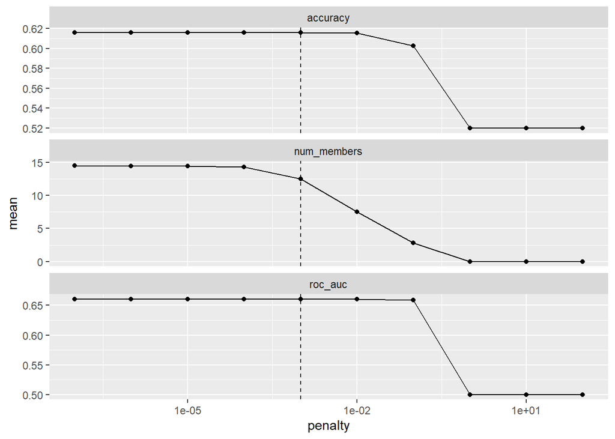

```r
library(yardstick)
library(tidyverse)
library(ggplot2)
library(ggfortify)
stack_model_st = read_rds("stack_model_st.rds")

autoplot(stack_model_st)
```

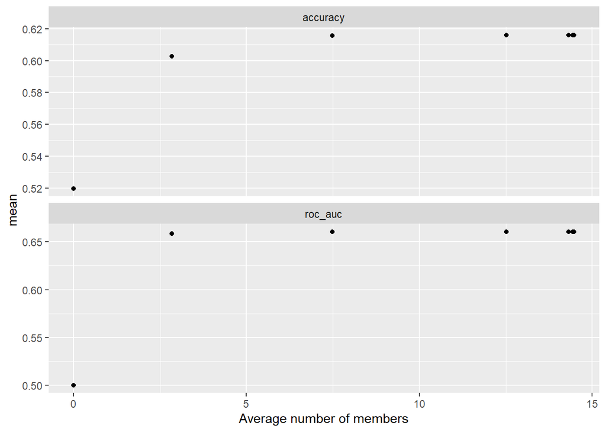

```r
autoplot(stack_model_st, type = "members")
```

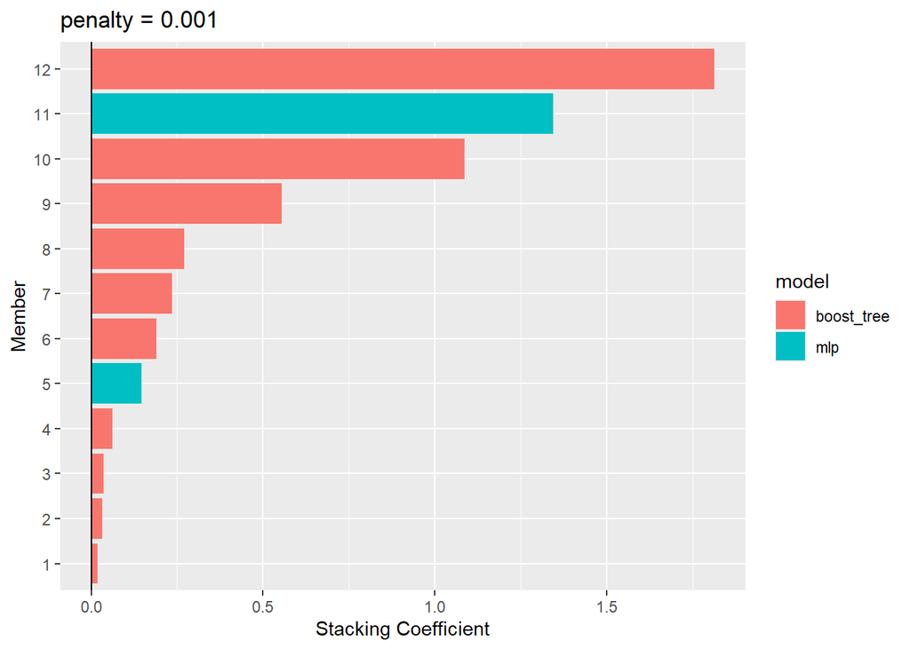

```r
autoplot(stack_model_st, type = "weights")
```

```r
collect_parameters(stack_model_st, "logit_res")
```

```
# A tibble: 17 × 5
   member          penalty mixture terms                      coef
   <chr>             <dbl>   <dbl> <chr>                     <dbl>
 1 logit_res_1_01 0.000001    0    .pred_TRUE_logit_res_1_01     0
 2 logit_res_1_05 0.0278      0    .pred_TRUE_logit_res_1_05     0
 3 logit_res_1_06 0.359       0    .pred_TRUE_logit_res_1_06     0
 4 logit_res_1_07 4.64        0    .pred_TRUE_logit_res_1_07     0
 5 logit_res_1_11 0.000001    0.25 .pred_TRUE_logit_res_1_11     0
 6 logit_res_1_14 0.00215     0.25 .pred_TRUE_logit_res_1_14     0
 7 logit_res_1_15 0.0278      0.25 .pred_TRUE_logit_res_1_15     0
 8 logit_res_1_16 0.359       0.25 .pred_TRUE_logit_res_1_16     0
 9 logit_res_1_21 0.000001    0.5  .pred_TRUE_logit_res_1_21     0
10 logit_res_1_24 0.00215     0.5  .pred_TRUE_logit_res_1_24     0
11 logit_res_1_25 0.0278      0.5  .pred_TRUE_logit_res_1_25     0
12 logit_res_1_31 0.000001    0.75 .pred_TRUE_logit_res_1_31     0
13 logit_res_1_34 0.00215     0.75 .pred_TRUE_logit_res_1_34     0
14 logit_res_1_35 0.0278      0.75 .pred_TRUE_logit_res_1_35     0
15 logit_res_1_41 0.000001    1    .pred_TRUE_logit_res_1_41     0
16 logit_res_1_44 0.00215     1    .pred_TRUE_logit_res_1_44     0
17 logit_res_1_45 0.0278      1    .pred_TRUE_logit_res_1_45     0
```

```r
collect_parameters(stack_model_st, "gb_res")
```

```
# A tibble: 30 × 5
   member      tree_depth learn_rate terms                   coef
   <chr>            <int>      <dbl> <chr>                  <dbl>
 1 gb_res_1_01          1  0.00001   .pred_TRUE_gb_res_1_01     0
 2 gb_res_1_02          2  0.00001   .pred_TRUE_gb_res_1_02     0
 3 gb_res_1_03          3  0.00001   .pred_TRUE_gb_res_1_03     0
 4 gb_res_1_04          1  0.0000599 .pred_TRUE_gb_res_1_04     0
 5 gb_res_1_05          2  0.0000599 .pred_TRUE_gb_res_1_05     0
 6 gb_res_1_06          3  0.0000599 .pred_TRUE_gb_res_1_06     0
 7 gb_res_1_07          1  0.000359  .pred_TRUE_gb_res_1_07     0
 8 gb_res_1_08          2  0.000359  .pred_TRUE_gb_res_1_08     0
 9 gb_res_1_09          3  0.000359  .pred_TRUE_gb_res_1_09     0
10 gb_res_1_10          1  0.00215   .pred_TRUE_gb_res_1_10     0
# ℹ 20 more rows
```

```r
collect_parameters(stack_model_st, "mlp_res")
```

```
# A tibble: 25 × 5
   member       hidden_units penalty terms                    coef
   <chr>               <int>   <dbl> <chr>                   <dbl>
 1 mlp_res_1_01            1   0.01  .pred_TRUE_mlp_res_1_01  0
 2 mlp_res_1_02            2   0.01  .pred_TRUE_mlp_res_1_02  0
 3 mlp_res_1_03            3   0.01  .pred_TRUE_mlp_res_1_03  0
 4 mlp_res_1_04            4   0.01  .pred_TRUE_mlp_res_1_04  1.34
 5 mlp_res_1_05            5   0.01  .pred_TRUE_mlp_res_1_05  0
 6 mlp_res_1_06            1   0.178 .pred_TRUE_mlp_res_1_06  0
 7 mlp_res_1_07            2   0.178 .pred_TRUE_mlp_res_1_07  0
 8 mlp_res_1_08            3   0.178 .pred_TRUE_mlp_res_1_08  0
 9 mlp_res_1_09            4   0.178 .pred_TRUE_mlp_res_1_09  0
10 mlp_res_1_10            5   0.178 .pred_TRUE_mlp_res_1_10  0
# ℹ 15 more rows
```

```r
library(yardstick)

stack_pred <- mimic_test %>%
  bind_cols(predict(stack_model_st, ., type = "prob")) %>%
  print(width = Inf)
```

```
# A tibble: 36,591 × 29
   subject_id  hadm_id  stay_id first_careunit
        <int>    <int>    <int> <fct>
 1   10000032 29079034 39553978 Medical Intensive Care Unit (MICU)
 2   10001217 24597018 37067082 Surgical Intensive Care Unit (SICU)
 3   10001217 27703517 34592300 Surgical Intensive Care Unit (SICU)
 4   10001725 25563031 31205490 Medical/Surgical Intensive Care Unit (MICU/SICU)
 5   10002013 23581541 39060235 Cardiac Vascular Intensive Care Unit (CVICU)
 6   10002155 23822395 33685454 Other
 7   10002428 28662225 33987268 Medical Intensive Care Unit (MICU)
 8   10002428 28662225 38875437 Medical Intensive Care Unit (MICU)
 9   10002430 26295318 38392119 Other
10   10002495 24982426 36753294 Other
   admission_type              admission_location     insurance language
   <fct>                       <fct>                  <chr>     <chr>
```

[output cut: 71 more lines]

```r
roc_auc(
  stack_pred,
  truth = los_long,
  contains(".pred_FALSE")
  )
```

```
# A tibble: 1 × 3
  .metric .estimator .estimate
  <chr>   <chr>          <dbl>
1 roc_auc binary         0.659
```

```r
# Register doParallel as the parallel backend
# saving 2 cpu for other tasks
registerDoParallel(cores = detectCores()-2)

stack_pred <-
  mimic_test %>%
  select(los_long) %>%
  bind_cols(
    predict(
      stack_model_st,
      mimic_test,
      type = "class",
      members = TRUE
      )
    ) %>%
  print(width = Inf)

# stop the registered parallel backend
stopImplicitCluster()
write_rds(stack_pred, "stack_model_pred.rds")
```

```r
library(yardstick)
library(tidyverse)
stack_pred = read_rds("stack_model_pred.rds")

stack_pred
```

```
# A tibble: 36,591 × 14
   los_long .pred_class .pred_class_gb_res_1_19 .pred_class_gb_res_1_25
   <fct>    <fct>       <fct>                   <fct>
 1 FALSE    TRUE        TRUE                    TRUE
 2 FALSE    FALSE       TRUE                    TRUE
 3 FALSE    FALSE       TRUE                    TRUE
 4 FALSE    TRUE        TRUE                    TRUE
 5 FALSE    FALSE       TRUE                    TRUE
 6 TRUE     TRUE        TRUE                    TRUE
 7 TRUE     TRUE        TRUE                    TRUE
 8 TRUE     TRUE        TRUE                    TRUE
 9 TRUE     TRUE        TRUE                    FALSE
10 TRUE     TRUE        TRUE                    FALSE
# ℹ 36,581 more rows
# ℹ 10 more variables: .pred_class_gb_res_1_17 <fct>,
#   .pred_class_gb_res_1_20 <fct>, .pred_class_gb_res_1_26 <fct>,
#   .pred_class_gb_res_1_15 <fct>, .pred_class_gb_res_1_18 <fct>,
#   .pred_class_gb_res_1_21 <fct>, .pred_class_gb_res_1_24 <fct>,
#   .pred_class_gb_res_1_30 <fct>, .pred_class_mlp_res_1_04 <fct>,
#   .pred_class_mlp_res_1_15 <fct>
```

```r
map(
  colnames(stack_pred),
  ~mean(stack_pred$los_long == pull(stack_pred, .x))
  ) %>%
  set_names(colnames(stack_pred)) %>%
  as_tibble() %>%
  pivot_longer(c(everything(), -los_long))
```

```
# A tibble: 13 × 3
   los_long name                     value
      <dbl> <chr>                    <dbl>
 1        1 .pred_class              0.613
 2        1 .pred_class_gb_res_1_19  0.605
 3        1 .pred_class_gb_res_1_25  0.452
 4        1 .pred_class_gb_res_1_17  0.612
 5        1 .pred_class_gb_res_1_20  0.602
 6        1 .pred_class_gb_res_1_26  0.446
 7        1 .pred_class_gb_res_1_15  0.610
 8        1 .pred_class_gb_res_1_18  0.614
 9        1 .pred_class_gb_res_1_21  0.592
10        1 .pred_class_gb_res_1_24  0.520
11        1 .pred_class_gb_res_1_30  0.444
12        1 .pred_class_mlp_res_1_04 0.576
13        1 .pred_class_mlp_res_1_15 0.585
```

### 4.

Compare model classification performance on the test set. Report both the area under ROC curve and accuracy for each machine learning algorithm and the model stacking. Interpret the results. What are the most important features in predicting long ICU stays? How do the models compare in terms of performance and interpretability?